# 2018 Total Polyphenols

Total polyphenols were measured by Amma Agyei using the Folin-Ciocalteau assay Spring of 2019.

# Read in data

Total polyphenols data, leafhopper density data, and leaf damage data

```r
tp <- read_csv(here("data", "raw", "2018 total polyphenols.csv"))
damage <- read_rds(here('data', 'cleaned', '2018_treatment_data.rds'))
```

Join data sheets.

| cultivar | n |
| --- | --- |
| J | 24 |
| L | 19 |

- sample: cultivar and sample ID. Q = qing xin da mao
- standard_deviation: from averaging triplicates
- mean_ga_equivalent: galic acid equivalents in mg/mL (i think)
- coefficient_of_variation: from averaging triplicates(?)
- leaf_density: leafhopper density at end of experiment in insects/young leaf
- mg_tea: mg of tea powder
- mg_g_gae: galic acid equivalents in mg/g of tea powder

These data are means of triplicate runs.

# Regression with leafhopper density as predictor

```r
shapiro.test(tp2$mg_g_gae)
```

```
    Shapiro-Wilk normality test

data:  tp2$mg_g_gae
W = 0.94629, p-value = 0.04369
```

```r
#normal enough
```

```r
lmtest::lrtest(dens.linear.cv)
```

```
Likelihood ratio test

Model 1: mg_g_gae ~ density_end * cultivar
Model 2: mg_g_gae ~ 1
  #Df  LogLik Df  Chisq Pr(>Chisq)
1   5 -51.759
2   2 -52.918 -3 2.3187      0.509
```

The null model wins. No effect of cultivar or leafhopper density on total polyphenols.

# Relationship between density and damage

J23 has really high damage. It has 3 completely dead leaves, which maybe should be excluded.

For example:

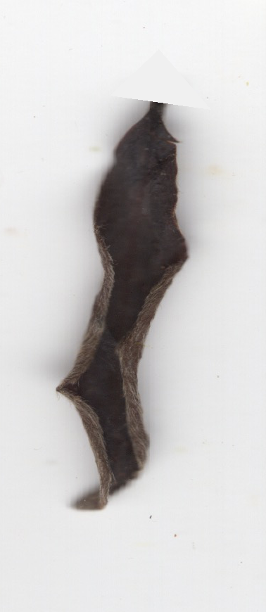

# Regression with %damage as predictor

```r
Anova(dam.linear)
```

```
Anova Table (Type II tests)

Response: mg_g_gae
                    Sum Sq Df F value  Pr(>F)
mean_percent_damage  2.901  1  4.4703 0.04061 *
Residuals           26.607 41
---
Signif. codes:  0 ‘***’ 0.001 ‘**’ 0.01 ‘*’ 0.05 ‘.’ 0.1 ‘ ’ 1
```

Now the model without cultivar is the best fit and shows a moderate linear relationship between damage and total polyphenols.

J23 is an obvious outlier. Without it:

## If I remove sample J23…

```r
Anova(dam.linear)
```

```
Anova Table (Type II tests)

Response: mg_g_gae
                     Sum Sq Df F value Pr(>F)
mean_percent_damage  0.0388  1  0.0606 0.8068
Residuals           25.5944 40
```

Now the null model is best and there is no longer an effect of % damage.

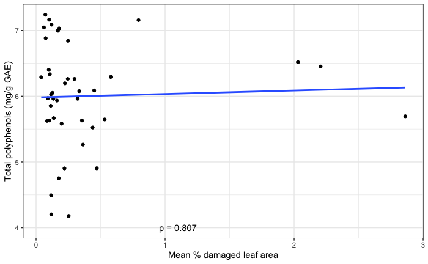

```r
p3 <-
  ggplot(tp3, aes(x = mean_percent_damage, y = mg_g_gae)) +
  geom_point() +
  # gghighlight(mean_percent_damage > 7, label_key = sample, use_direct_label = TRUE) +
  geom_smooth(method = "lm", formula = "y ~ x", se = FALSE) +
  labs(x = "Mean % damaged leaf area",
       y = "Total polyphenols (mg/g GAE)") +
  theme_bw() +
  annotate(geom = "text", x = 1.1, y = 4, label = glue("p = {round(Anova(dam.linear)$`Pr(>F)`[1], 3)}"))
p3
```